# Long-term dynamics of demographic and taxonomic parameters

```r
library(knitr)
opts_chunk$set(echo = TRUE, message = FALSE, warning = FALSE)
```

```r
library(vegan)
library(dplyr)
library(ggplot2)
library(mgcv)
library(readxl)

theme_set(theme_bw())
```

```r
tuv_all <- read.table("Data/TuMyt_all_itog.csv", header = T, sep = ";")

tuv_all$Habitat <- factor(tuv_all$Habitat)

# tuv_all$Fitros <- 2 * asin(sqrt(tuv_all$Ptros)) * 180/pi

tuv_all <- tuv_all %>% mutate(Age_4_7 = Age4 + Age5 + Age6 + Age7, Age_8_12 = Age8 + Age9 + Age10 + Age11 + Age12)

ptros_gen <- read_excel("Data/Ptros_gen.xlsx")
```

**Att!** Я предлагаю убрать из основного текста все рассказы про PERMANOVA и SIMPER, как лишние сущности. Для обоснования введения этих методов надо вводить понятие “Period”, обосновывать почему мы его вводим и т.д. Много и ненужно. Это можно убрать в приложение как отдельное подтверждение того, что что-то пменялось. Все то же самое показывет более правильный и более одннотипно организованный анализ на основе GAM. Кроме того, я считаю лишним сопоставление CCA и СA (я и сам не понимаю, что имеет ввиду ППС). CA - это всего лишь способ уйт от многих демографических параметров к двум информативным главным осям. Сама ординация в осях CA, в принципе, тоже лишняя, но с треком-червяком, согласен, что-то говорит про то, что в ней зашита еще и динамика. Соответсвтенно, текст, приведенный ниже, мое видение того, как надо описывать динамику.

## For M&M

We investigated two aspects of long-term dynamics of mussel settlement in the Tuva inlet. Firstly we analyzed changes in the demographic structure of settlements and secondly - the changes in the taxonomic structure. For the first purpose we applied correspondence analysis based on the matrix of demographic parameters (see above). Values of CA-scores for settlements were considered as a complex characteristic of demographic structure and used as a dependent variable for regression model building. This model was constructed as a generalized additive model (GAM, normal distribution) with Year and Habitat as predictors. Smoothers for each habitat were fitted separately (Model type “I” according to Pedersen et al., 2019) and habitat was considered as random effect (Pedersen et al., 2019).

## For results

```r
tuv_all2 <-
tuv_all %>% select(Sample_ID, Period, Year, Habitat, Age2_3, Age4_6, Age7_9, Age10_12, N, W, OGP, max_L, size_5) %>% as.data.frame() %>% filter(complete.cases(.))


tuv_ca <- cca(tuv_all2[,-c(1:4)])



tuv_ca_f <- scores(tuv_ca, scaling = "symmetric")
tuv_ca_f_site <- as.data.frame(tuv_ca_f$sites)
tuv_all2$Period <- factor(tuv_all2$Period)
tuv_ca_f_site$Period <- tuv_all2$Period
tuv_ca_f_site$Habitat <- tuv_all2$Habitat
tuv_ca_f_site$Sample_ID <- tuv_all2$Sample_ID

tuv_ca_f_sp <- as.data.frame(tuv_ca_f$species)


# чтобы добавить стрелочки для банки
BS_05 <- tuv_ca_f_site %>%  filter(Sample_ID %in% c('BS_0.5_04', 'BS_0.5_09', 'BS_0.5_10', 'BS_0.5_12', "BS_0.5_18"))

ca_all_period <-
  ggplot(tuv_ca_f_site, aes(x = CA1, y = CA2)) +
  geom_vline(xintercept = 0) +
  geom_hline(yintercept = 0) +
  theme_bw() +
  geom_point(aes(fill = Period, shape = Habitat, size = Habitat, color = Period)) +
  scale_size_manual(values = c(5, 4, 4, 4.5)) +
  scale_fill_manual(values = c("red", "black", "cyan3", "orange")) +
  scale_color_manual(values = c("black", "yellow", "black", "black")) +
  scale_shape_manual(values = c(21, 23, 24, 22)) +
  geom_text(data = tuv_ca_f_sp, aes(label = row.names(tuv_ca_f_sp)), color = "darkviolet", size = 3) +   theme(legend.position ="") +
  scale_y_reverse() +
  geom_path(data = BS_05, aes(x = CA1, y = CA2), color = "blue", size = 0.9, linetype = 3, arrow = arrow(type = "closed", angle = 7))
```

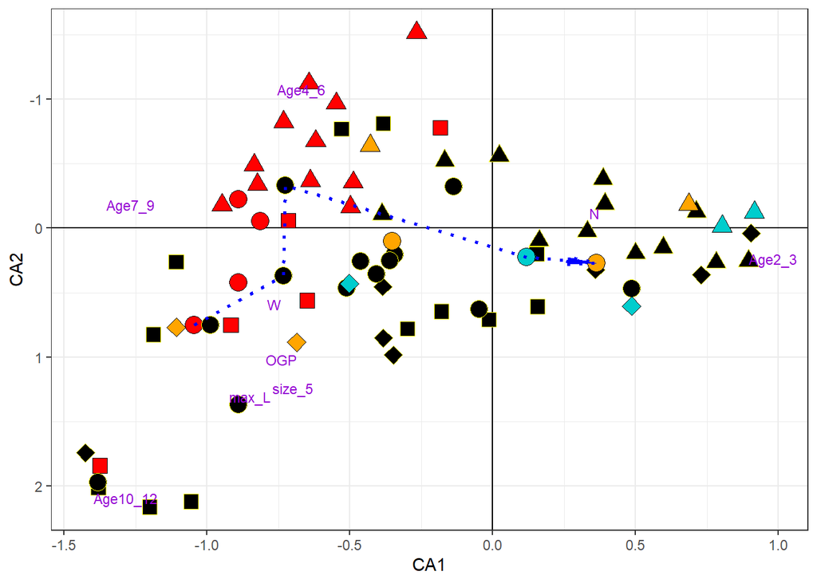

```r
ca_all_period
```